# Introduction

Ross, M. and Pawley, A. and Osmond, M.

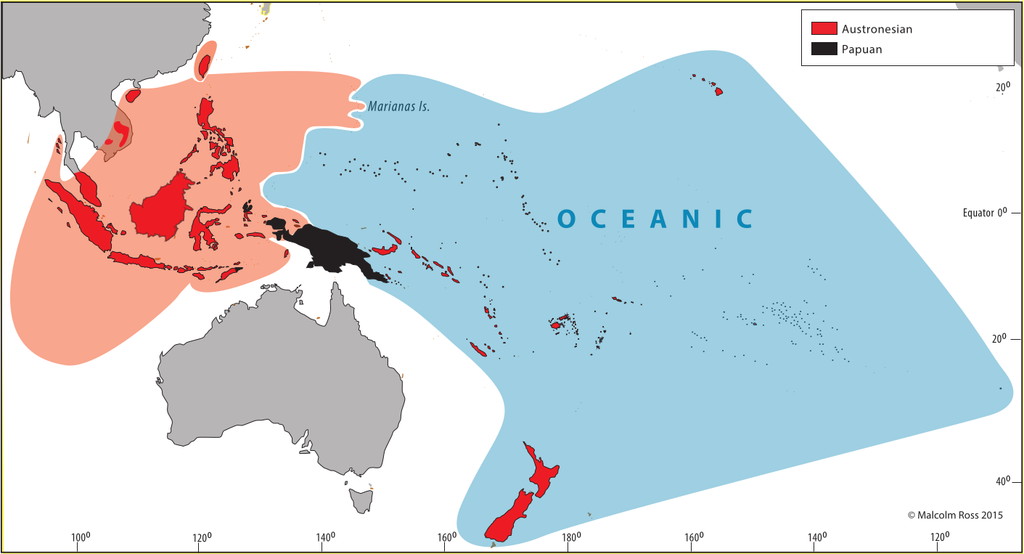

**Map 1.1:** Oceanic and non-Oceanic Austronesian languages

## 1. Aims[^1]

This is the sixth and last of a set of volumes on the lexicon of the Proto Oceanic (POc) language.[^2] POc was the immediate ancestor of the Oceanic subgroup of the Austronesian language family. This subgroup consists of all the Austronesian languages of Melanesia east of 136˚ E, together with those of Polynesia and, with two exceptions, those of Micronesia—around 500 languages in all (see Map 1.1).[^3] Extensive arguments for the existence of Oceanic as a clearly demarcated branch of Austronesian were first put forward by Dempwolff (1927, 1937), and the validity of the subgroup is now recognised by probably all scholars working in Austronesian historical linguistics.

The development and break-up of the POc language and speech community were stages in a truly remarkable chapter in human prehistory—the colonisation by Austronesian speakers of the Indo-Pacific region in the period after about 2000 BC. The outcome was the largest of the world’s well-established language families and (until the expansion of Indo-European after Columbus) the most widespread. The Austronesian family comprises more than 1,000 distinct languages. Its eastern and western outliers, Madagascar and Easter Island, are two-thirds of a world apart, and its northernmost extensions, Hawai‘i and Taiwan, are separated by 70 degrees of latitude from its southernmost outpost, Stewart Island in New Zealand.

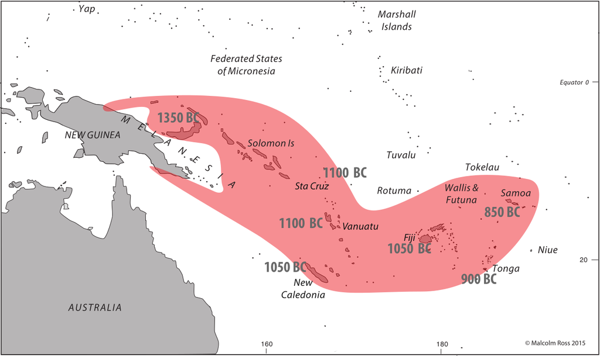

**Map 1.2:** Geographic limits of historically identified Oceanic speakers and presently documented Lapita sites

The present project brings together a large corpus of lexical reconstructions for POc, with supporting cognate sets, organised according to semantic fields and using a standard orthography for POc. We hope that it will be a useful resource for culture historians, archaeologists and others interested in the prehistory of the Pacific region. The comparative lexical material should also be a rich source of data for various kinds of purely linguistic research, e.g. on subgrouping (as in §1.8 and §1.9), phonological change, semantic change and semantic structure (e.g. colexification) in the 500 or so daughter languages.

Volume 1 of *The lexicon of Proto Oceanic* reconstructs terms associated with material culture. Volumes 2, 3 and 4 examine relevant sets of cognate terms that provide insights into how POc speakers viewed their environment. Volume 2 deals with the geophysical or inanimate environment, and volumes 3 and 4 treat plants and animals respectively. Volume 5 and the present volume return to terminologies centring on people. Volume 5 concerns gender and age, the body, and human conditions and physical and cognitive activities that arise from nature rather than nurture. The present volume concerns culturally learned structures, including social organisation, beliefs in the supernatural, the seasons of the year, counting and other elements of non-material culture.

A consideration of the totality of our reconstructions across volumes 1 to 5 has led to an unexpected reassessment of the origin of Proto Oceanic (§§1.8–1.9) together with a small revision to its phonology (§1.8.2.4).

The editors had intended to provide a seventh volume that would perform several functions. It would treat closed classes of lexical roots; review the project’s main findings concerning Proto Oceanic speakers’ culture and environment and compare these findings with what archaeology tells us about the way of life and environment of the bearers of the Lapita culture. Some of these matters are partially folded into the chapters of the present volume, e.g. social anthropology into chapters 3 and 4, archaeology into chapter 5 and archaeogenetics briefly into chapter 15. Two factors have led to the decision not to proceed with volume 7 and to make this the last volume. Firstly, the editors are now octogenarians and would like to live somewhat less hectic lives. Secondly, and importantly, funds have been provided by the (Australian Research Council’s) Centre of Excellence for the Dynamics of Language to set up a publicly accessible electronic database of the reconstructions from the six volumes along with their supporting data, thereby fulfilling at least the purposes of the cumulative indexes intended for volume 7. It will also provide a locus for updating the project’s findings and for additions by other scholars.

## 2. The present volume

Inspection of the table of contents shows that the chapters in the present volume vary hugely in length. Each chapter concerns a semantic domain. For some of these domains—kinship, seasonal cycles, counting—we found a wealth of data and were dealing with internally structured closed classes of lexemes whose presentation required numerous tables (and diagrams in the case of kinship). For other domains—the spirit world, measurement—there was limited lexical material, and for yet others—*mana, *tabu—the author chose to limit domains to single concepts considered by others to be key cultural concepts in the Oceanic lexicon.

Chapters 2 to 5 of this volume are concerned with POc speakers’ social organisation. Chapter 2 is a detailed reconstruction of kinship terms and structures. Chapter 3, by the late Per Hage, is a slightly edited and abridged version of a paper first published in *The Journal of the Polynesian Society* in 2007. It complements chapter 2 by using evidence from disciplines other than linguistics to answer the question, “Was POc society matrilineal?” Chapter 4 returns to a much discussed issue, reconstructing terms associated with chieftainship and rank in POc and examining the consequences of this reconstruction.[^4] Chapter 5 uses reconstructed terms to investigate POc speakers’ settlement patterns.

Chapter 6 concerns the probable recreational activities of POc speakers, looking at music, song, dance and games.

In chapters 7 to 10 we turn to topics that have to do with belief systems and the supernatural. Chapter 7 concerns the beings that inhabited the POc spirit world. Chapters 8 and 9 both deal with human manipulation of the supernatural. Chapter 8 takes a broad look at magic, while chapter 9 focuses on the reconstruction of PEOc *mana, a term that has been much discussed by Pacific anthropologists and denotes the pervasive supernatural power given by ancestral spirits to certain powerful individuals to ensure their success. Chapter 10 analyses the meanings of the POc term *tabu, which has reflexes throughout Oceanic. It meant ‘prohibited’, but in certain EOc languages it also attributes an aura of sanctity to the ‘prohibited’ person or object.

Chapter 11 investigates in some detail the way that Oceanic speakers have referred to the cyclic nature of time and have used the sun, moon and stars to regulate the agricultural cycle.

The terms that POc speakers used to refer to various aspects of speech are the subject of chapter 12.

Chapter 13 reconstructs terms that had to do with trade and more generally with change of possession: giving, receiving and stealing. It also introduces the practice of ceremonial exchange, which plays a role in chapter 14 on counting. There it is argued that the POc decimal counting system and its associated complexities were kept alive by their use in ceremonial exchange feasts. Chapter 15 suggests that POc may also have had a digit-tally system used in everyday counting. One counting complexity covered in chapter 14 is the use of numeral classifiers, and chapter 16 deals with the subset of classifiers used in measurement.

Appendix A lists the data sources employed in this volume. Appendix B lists the languages from which data for this and previous volumes are drawn. It includes alternative names of languages, an index to languages, maps showing their approximate locations, and a list of their ISO codes, glottocodes and longitudes and latitudes.

## 3. The relation of the current project to previous work

Reconstructions of POc phonology and lexicon began with Dempwolff’s pioneering work in the 1920s and 1930s. Dempwolff’s dictionary of reconstructions attributed to Proto Austronesian (PAn) (Dempwolff 1938)—but equivalent in modern terms to Proto Malayo-Polynesian (PMP)—includes some 600 reconstructions with reflexes in Oceanic languages.

Since the 1950s, POc and other early Oceanic interstage languages have been the subject of a considerable body of research. However, relatively few new reconstructions safely attributable to POc were added to Dempwolff’s material until the 1970s. In 1969 George Grace made available as a working paper a compilation of reconstructions from various sources amounting to some 700 distinct items, attributed either to POc or to early Oceanic interstages. These materials were presented in a new orthography for POc, based largely on Biggs’ (1965) orthography for an interstage he called Proto Eastern Oceanic. Updated compilations of Oceanic cognate sets were produced at the University of Hawai‘i in the period 1977–1983 as part of a project directed by Grace and Pawley. These compilations and the supporting data are problematic in various respects and we have made only limited use of them.

Comparative lexical studies have been carried out for several lower-order subgroups of Oceanic: for Proto Polynesian by Biggs (resulting in Walsh & Biggs 1966, Biggs, Walsh & Waqa 1970 and subsequent versions of the POLLEX file, including Biggs & Clark 1993, Clark & Biggs 2006 and online as Greenhill & Clark 2011); for Proto Micronesian by scholars associated with the University of Hawai‘i (Bender et al. 1983, 2003a, 2003b); for the ancestor of the Banks and Torres languages by Alexandre François (several unpublished manuscripts); for Proto North and Central Vanuatu by Clark (2009); for Proto Southern Vanuatu by Lynch (2001c); for New Caledonia by Ozanne-Rivierre (1992), Haudricourt & Ozanne-Rivierre (1982) and Geraghty (1989); for Proto SE Solomonic by Levy (1980) and Lichtenberk (1988); for Proto Central Pacific by Hockett (1976), Geraghty (1983, 1986, 1996, together with a number of unpublished papers); for Proto Eastern Oceanic by Biggs (1965), Cashmore (1969), Levy (1980), and Geraghty (1990); and for Proto Central Papuan by Pawley (1975), Lynch (1978a, 1980), and Ross (1994a).

Robert Blust (1970, 1980a, 1983-84a, 1986, 1989) of the University of Hawai‘i, in a series of papers published extensive, alphabetically ordered, lexical reconstructions (with supporting cognate sets) for interstages earlier than POc, especially for Proto Austronesian, Proto Malayo-Polynesian and Proto Eastern Malayo-Polynesian. He has also written several papers investigating specific semantic fields (Blust 1980c, 1982b, 1987, 1994). Blust & Trussel had a major work in progress, the online Austronesian Comparative Dictionary (ACD), which brings together Blust’s reconstructions for Proto Austronesian and lower-order stages up to mid 2020, when the sudden death of Steve Trussel, who was responsible for the web interface and data input, brought this work to a sudden halt. With the passing of Robert Blust in January 2022, theACDwas bequeathed to Alexander Smith and found a new home with the Cross-Linguistic Linked Data project, where hopefully it will continue to grow.[^5]

Several papers predating our project systematically investigated particular semantic domains in the lexicon of POc, e.g. Milke (1958b), French-Wright (1983), Pawley (1982a, 1985), Pawley & Green (1984), Lichtenberk (1986), Walter (1989), and the various papers in Pawley & Ross (1994). Ross (1988) contained a substantial number of new POc lexical reconstructions, as well as proposed modifications to the reconstructed POc sound system and the orthography. However, previous Oceanic lexical studies were limited both by large gaps in the data, with a distinct bias in favour of ‘Eastern Oceanic’ languages, and by the technical problems of collating large quantities of data. Although many languages in Melanesia remain poorly described, there are now many more dictionaries and extended word lists, particularly for Papua New Guinea, than there were in the 1980s. And developments in computing hardware and software now permit much faster and more precise handling of data than was possible then. A list of sources is found in Appendix A.

Several compilations of reconstructions have provided valuable points of reference, both inside and outside the Oceanic group. We are indebted particularly to Bender et al. (2003a, 2003b), two editions of POLLEX (Biggs & Clark 1993 and Clark & Biggs 2006), Blust & Trussel (2020), Clark (2009) and Lynch (2001c).

In the course of planning the several volumes of the present project, we came to realise that the form in which preliminary publications were presented—namely as essays, each discussing cognate sets for a particular semantic field at some length—would also be the best form for the presentation of this set of volumes. A discursive treatment of individual terminologies, as opposed, say, to a dictionary-type listing of reconstructions with supporting cognate sets, makes it easier to relate the linguistic comparisons to relevant issues of culture history, language change, and methodology. Hence each of the present volumes has as its core a collection of analytic essays. Some of these have been published or presented elsewhere, but are included here in revised form.

In some cases we have updated the earlier versions in the light of subsequent research, and, where appropriate, have inserted cross-references between contributions. Authorship is in some cases hard to pin down, as a number of people have had a hand in collating the data, doing the reconstructions, and (re)writing for publication here. In most chapters, however, one person did the research which determined the structure of the terminology, and that person appears as the first or only author, and where another or others had a substantial part in putting together the chapter they appear as the second or further authors.

## 4. Reconstructing the lexicon

### 4.1. Terminological reconstruction

Our method of doing ‘terminological reconstruction’ is as follows. First, the terminologies of present-day speakers of Oceanic languages are used as the basis for constructing a hypothesis about the semantic structure of a corresponding POc terminology, taking account of (i) ethnographic evidence, i.e. descriptions of the lifestyles of Oceanic communities and (ii) the geographical and physical resources of particular regions of Oceania. For example, by comparing terms in several languages for parts of an outrigger canoe, or for growth stages of a coconut, one can see which concepts recur and so are likely to have been present in POc. Secondly, a search is made for cognate sets (§1.4.2), i.e. words from different languages that appear to be descended from the same protoform, from which forms can be reconstructed to match each meaning in this hypothesised terminology. The search is not restricted to members of the Oceanic subgroup; if a term found in an Oceanic language proves to have external (non-Oceanic) cognates, the POc antiquity of that term will be confirmed and additional evidence concerning its meaning will be provided. Thirdly, the hypothesised terminology is re-examined to see if it needs modification in the light of the reconstructions. There are cases, highlighted in the various contributions to these volumes, where we were able to reconstruct a term where we did not expect to do so and conversely, often more significantly, where we were unable to reconstruct a term where we had believed we should be able to. In each case, we have discussed the reasons why our expectations were not met and what this may mean for Oceanic culture history. We have set out to pay more careful attention to reconstructing the semantics of POc forms than has generally been done in earlier work, treating words not as isolates but as parts of terminologies.

Blust (1987:81) distinguishes between conventional ‘semantic reconstruction’, which asks, “What was the probable meaning of protomorpheme X?”, and Dyen and Aberle’s (1974) ‘lexical reconstruction’, where one asks, “What was the protomorpheme which probably meant ‘X’?” At first sight, it might appear that terminological reconstruction is a version of lexical reconstruction. However, there are sharp differences. Lexical reconstruction applies a formal procedure: likely protomeanings are selected from among the glosses of words in available cognate sets, then an algorithm is applied to determine which meaning should be attributed to each set. This procedure may have unsatisfactory results, as Blust points out. Reconstructions may end up with crude and overly simple glosses; or no meaning may be reconstructed for a form because none of the glosses of its reflexes is its protomeaning.

Terminological reconstruction is instead similar to the semantic reconstruction approach. In terminological reconstruction the meanings of protomorphemes are not determined in advance. Instead, cognate sets are collected and their meanings are compared with regard to:

- their specific denotations, where these are known;
- the geographic and genealogical distribution of these denotations (i.e. are the glosses from which the protogloss is reconstructed well distributed?);
- any derivational relationships to other reconstructions;
- their place within a working hypothesis of the relevant POc terminology (e.g., are terms complementary —‘bow’ implies ‘arrow’; ‘seine net’ implies ‘floats’ and ‘weights’? Are there different levels of classification—generic, specific, and so on?).

For example, it proved possible to reconstruct the following POc terms for tying with cords (vol.1:290–293):

- POc *buku ‘tie (a knot); fasten’
- POc *pʷita ‘tie by encircling’
- POc *paqu(s), *paqus-i- ‘bind, lash; construct (canoe +) by lashing together’
- POc *pisi ‘bind up, tie up, wind round, wrap’
- POc *kiti ‘tie, bind’

In each of the supporting cognate sets from contemporary languages there are a number of items whose glosses in the dictionaries or word lists are too vague to tell the analyst anything about the specific denotation of the item, and in the case of *kiti this prevents the assignment of a more specific meaning. The verb *buku can be identified as the generic term for tying a knot because of its derivational relationship (by zero derivation) with a noun whose denotation is clearly generic, *buku ‘node (as in bamboo or sugarcane); joint; knuckle; knot in wood, string or rope’ (vol.1:85–86). Other senses are extensions of this meaning (vol.2:50, vol.5:159, 175–176, 341). Reconstruction of the meaning of *pʷita as ‘tie by encircling’ is supported by the meanings of the Lukep, Takia and Longgu reflexes, respectively ‘tie by encircling’, ‘tie on (as grass-skirt)’, and ‘trap an animal’s leg; tie s.t. around ankle or wrist’: Lukep and Takia are North New Guinea languages, whilst Longgu is SE Solomonic. Reconstruction of the meaning of *paqu(s), *paqus-i- as ‘bind, lash; construct (canoe +) by tying together’ is supported by the meanings of the Takia, Kiribati and Samoan reflexes, respectively ‘tie, bind; construct (a canoe)’, ‘construct (canoe, house)’, and ‘make, construct (wooden objects, canoes +)’: Takia is a North New Guinea language, Kiribati is Micronesian, and Samoan is Polynesian. The meaning of *pisi is similarly reconstructed by reference to the meanings of its Mono-Alu, Mota, Port Sandwich, Nguna and Fijian reflexes.

Often, however, the authors have been less fortunate in the information available to them. For example, Osmond (vol.1:222–225) reconstructs six POc terms broadly glossed as ‘spear’. Multiple terms for implements within one language imply that these items were used extensively and possibly in specialised ways. Can we throw light on these specialised ways? Unfortunately, some of the word lists and dictionaries available give minimal glosses, e.g. ‘spear’, for reflexes of the six reconstructions. What we need to know for each reflex is: what is the level of reference? Is it a term for all spears, or perhaps all pointed projectiles including arrows and darts? Or does it refer to a particular kind of spear? Is it noun or verb or both? If a noun, does it refer to both the instrument and the activity? Most word lists are frustratingly short on detail. For this kind of detail, ethnographies have proven a more fruitful source of information than many word lists.

Another problem is inherent in the dangers of sampling from some 500 languages. The greater the number of languages, the greater are the possible variations in meaning of any given term, and the greater the chances of two languages making the same semantic leaps quite independently. Does our (sometimes quite limited) cognate set provide us with a clear unambiguous gloss, or have we picked up an accidental bias, a secondary or distantly related meaning? Did etymon x refer to fishhook or the material from which the fishhook was made? Did etymon y refer to the slingshot or to the action of spinning round?

### 4.2. Sound correspondences

Phonological changes, whereby one sound evolves into another, are mostly regular. For example, the initial consonant of the reflexes of the three words below is the same for all three items (and for numerous others).[^6] In each language all instances of initial *p- have evolved “regularly”, i.e., in the same way.

|  | POc | *papine | *pisiko | *pat[i] [^7] | *p- |
| --- | --- | --- | --- | --- | --- |
|  |  | ‘woman’ | ‘meat, flesh’ | ‘four’ |  |
| Adm: | Aua | *pifine* | *pirio* | — | *p-* |
| Adm: | Baluan | *pein* | *pusio* | *pa-* | *p-* |
| NNG: | Numbami | — | *wiso* | *wata* | *w-* |
| PT: | Kilivila | *vivila* | *viliy-na* | *-vasi* | *v-* |
| PT: | Yamalele | *vavine* | *viɣo* | — | *v-* |
| PT: | Sinaugoro | *vavine* | *vi-viɣo* | *vasi-vasi* | *v-* |
| PT: | Motu | *hahine* | *hidio* | *hani* | *h-* |
| MM: | Tolai | *vavina* | *vio* | *-vat* | *v-* |
| MM: | Vaghua | *vavene* | *vəzəɣo* | *-vac* | *v-* |
| SES: | Arosi | *haihine* | *hasiʔo* | *hai* | *h-* |
| NCV: | Mota | *vavine* | *visoɣo-i* | *vat* | *v-* |
| Mic: | Woleaian | *faifile* | *fitixo* | *faa-* | *f-* |
| Fij: | Wayan | *vavine* | *viðiko* | *vā* | *v-* |
| Pn: | Samoan | *fefine* | — | *fā* | *f-* |

The grouping to which each language belongs is indicated by an abbreviation on the left (§1.5.1).

The “sound correspondence” that concerns us here, the initial consonant correspondence, is shown on the right. Reconstructing forms in a protolanguage depends on working out the systematic sound correspondences among cognate vocabulary in contemporary languages and on having a working hypothesis about how the sounds of POc have changed and are reflected in modern Oceanic languages. Working out sound correspondences even for twenty languages is a large task, and so we have relied heavily on the work of others and our own previous work. The sound correspondences we have used are as follows: Ross (1988) for Western Oceanic and Admiralties; Ross (1996a) for Yapese; Ross (1996b) for Oceanic languages of Indonesian Papua; Pawley (1972) for Eastern Oceanic; Levy (1979, 1980) for SE Solomonic and Lichtenberk (1988) for Cristobal-Malaitan; Pawley (1972) and Tryon & Hackman (1983) for SE Solomonic; Ross & Næss (2007) for Temotu; François (pers. comm.) for the Banks and Torres Islands of Vanuatu; Tryon (1976) and Clark (2009) for North and Central Vanuatu; Lynch (2001c) for Southern Vanuatu; Geraghty (1989), Haudricourt & Ozanne-Rivierre (1982), Ozanne-Rivierre (1992, 1995) and Lynch (2015) for New Caledonia; Jackson (1986) and Bender et al. (2003a, 2003b) for Micronesian; Geraghty (1986) for Central Pacific; and Biggs (1978) for Polynesian. We have also done additional work on North and Central Vanuatu and New Caledonia ourselves.

For non-Oceanic languages we have referred to sound correspondences given by Tsuchida (1976) for Formosan languages; by Zorc (1977, 1986) and Reid (1982) for the Philippines; by Adelaar (1992b) and Nothofer (1975) for Malay and Javanese; by Sneddon (1984) for Sulawesi; by Collins (1983) for central Maluku; by Grimes & Edwards (in prep.) for what is conventionally known as CMP; and by Blust (1978a) and Kamholz (2014) for SHWNG.

Regular sound correspondences can be interfered with in various ways: by phonetic conditioning that the analyst has not identified (see, e.g., Blust 1996a), by borrowing (for an extreme Oceanic case, see Grace 1996), or by the frequency of an item’s use (Bybee 1994). We have tried at least to note, and sometimes to account for, irregularities in cognate sets.

### 4.3. The internal structure of the Oceanic subgroup of the Austronesian family

Figure 1.1 shows nine primary subgroups of Oceanic. Its rake-like structure indicates that no convincing body of shared innovations has been found to allow any of the nine subgroups to be combined into higher-order groupings. Section 1.4.3.1 explains the theory that underlies the formulation of Figure 1.1, which is important to the practice of reconstruction. Sections 1.4.3.2 and 1.4.3.3 offer some commentary on our subgrouping, and in §1.4.4 we explain how our criteria for making a reconstruction and attributing it to a protolanguage are related to subgrouping issues.

#### 4.3.1. Subgroups and linkages

In Figure 1.1 each node is, with one minor exception, either a single language, usually a reconstructed protolanguage, or, in italics, a group of languages. The exception is the two very closely related languages Mussau and Tench.

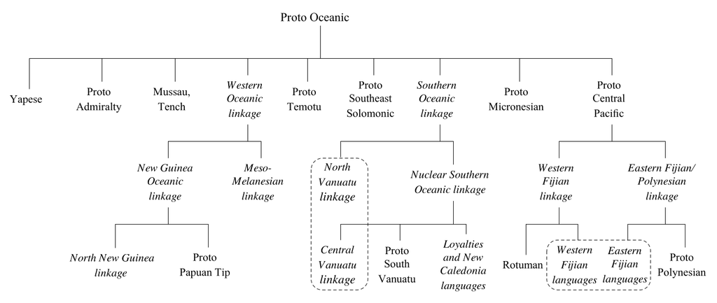

**Figure 1.1:** Schematic diagram showing the subgrouping of Oceanic Austronesian languages.

Where a node is a protolanguage, its descendants form a subgroup. The only descendant languages shown in Figure 1.1 are reconstructed protolanguages, but Appendix B lists by grouping the descendant languages referred to in these volumes. A subgroup is identified by innovations shared by its member languages, i.e. it is ‘innovation-defined’ in the terminology of Pawley & Ross (1995). These innovations are assumed to have occurred just once, in the subgroup’s protolanguage, i.e. the exclusively shared ancestor of its members. Thus languages of the large Oceanic subgroup of Austronesian share a set of innovations relative to the earlier Austronesian stages shown in Figure 1.5. By inference these innovations occurred in their common ancestor, POc, and the claim that they are innovations is based on a comparison of reconstructed POc with reconstructed PMP. The phonological innovations of POc were identified by Dempwolff (1934), and have been somewhat modified by subsequent research (§1.8.1). POc also reflects morphosyntactic innovations (Lynch et al. 2002: ch.4), morphological innovations (e.g. POc acquired a morphological distinction between three kinds of alienable possessive relationship: food, drink and general; Lichtenberk 1985a), and lexical innovations (e.g. PMP *limaw ‘citrus fruit’ was replaced by POc *molis; Lynch 1984).

Italics are used in Figure 1.1 to indicate a group of languages that is not a subgroup, i.e. has no identifiable exclusively shared parent. Thus Southern Oceanic linkage in Figure 1.1 indicates a collection of languages descended from POc (Ross 1988). They comprise the languages of Vanuatu, the Loyalties and New Caledonia, but they do not form a subgroup. There was no “Proto Southern Oceanic”, as no convincing innovation has been identified that is reflected by all Southern Oceanic languages. Nonetheless, there are innovations which chain various, sometimes overlapping, groups of Southern Oceanic languages together (§1.4.3.2). Some of these innovations are inherited, i.e. they define smaller subgroups within Southern Oceanic. Of these, Southern Vanuatu is the best known example (Lynch 2001c:181–184). Others are probably the result of contact between fairly similar languages. The recently discovered fact that there were multiple immigrations by, we take it, speakers of early Oceanic languages probably gave rise to this kind of contact (see the discussion in §15.8.1).

The term “linkage” occurs in several of the italicised labels in Figure 1.1. The distinction between a subgroup and a linkage is important in reconstruction.[^8]

A **subgroup** is defined by a set of coterminous innovations that are inferred to have occurred in its common ancestor (its protolanguage).[^9] By “coterminous” is meant that all the innovations are shared by all the languages of the group.[^10] This is the situation in Figure 1.2.[^11] Languages A and B share a set of innovations and form one subgroup. Languages C–J share another set of innovations and form another subgroup. The processes of language change that give rise to innovations are continuous, meaning that subgroup formation is recursive. Within the subgroup CDEFGHJ are two (sub)subgroups CDE and FG, alongside two languages H and J. This situation can be represented in two ways: by a tree (left) or a maplike representation (right). The tree, like Figure 1.1, also displays the protolanguages from which the languages of each subgroup are inferred to be descended.

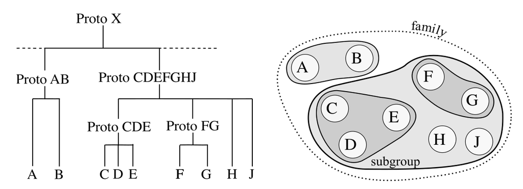

**Figure 1.2:** Schematic diagram of a subgroup

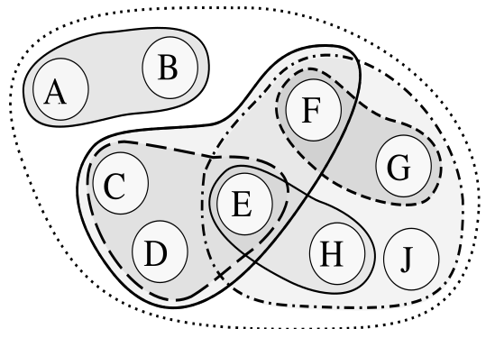

**Figure 1.4:** Schematic diagram of a linkage

Innovations begin as changes that occur in the language of an individual speaker, and some of these changes spread across the community. As long as languages are mutually intelligible, changes continue to spread. Their places of origin, and directions and extents of spread, may differ, so that the resulting innovations are not coterminous but instead intersect. And over time, social relationships may change, so that changes arrive from new origins. The outcome of these processes is a linkage.

However, untangling the history of a linkage is difficult, and sometimes impossible. In the “worst-case” scenario one or more innovations spreads right across the languages of the linkage. In this case it becomes virtually impossible to distinguish it from a subgroup. But returning to Figure 1.4, perhaps EFGHJ in fact reflects innovations that occurred in Proto EFGHJ. If so, then we cannot posit Proto CDEF or Proto CDE. Instead, we infer that at some date relationships were realigned so that speakers of pre-C and pre-D came into intimate enough contact with speakers of Proto EFGHJ or one of its descendants for innovations to pass between them, creating the illusion of a subgroup CDEF. But, with a little thought one could come up with a good number of scenarios that result in the pattern in Figure 1.4, and determining which reflects the actual history can be difficult.

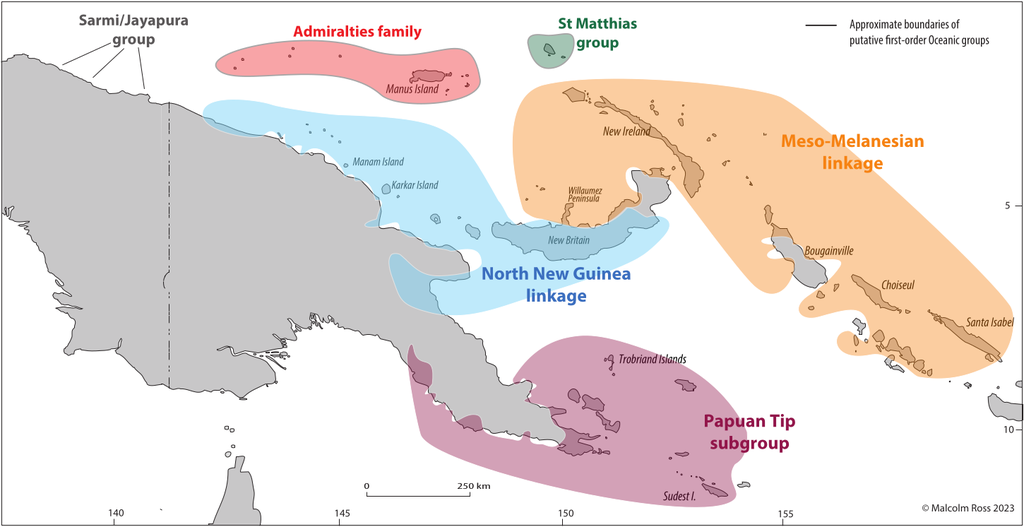

**Map 1.3:** Oceanic language groups in northwest Melanesia: the Admiralties and St Matthias groups and the subgroups of Western Oceanic.

It is tempting to see a subgroup and a linkage as opposing patterns, but comparison of Figure 1.4 with the righthand diagram of Figure 1.2 shows that a subgroup is a subtype of a linkage, one in which the ranges of innovations happen not to intersect (François 2014:171). Nonetheless, we maintain the distinction between a subgroup and a linkage, as the former reflects a reconstructable protolanguage but the latter does not (or sometimes, as emerges below, does so more weakly).

#### 4.3.2. Oceanic linkages

A number of Oceanic linkages have been recognised by scholars. They include Fijian (Geraghty 1983), the Caroline Islands (Jackson 1983), Vanuatu (Tryon 1976; Clark 1985; Lynch 2000b; 2004d; François 2011b, 2014), NW Melanesia (Ross 1988), the SE Solomons (Lichtenberk 1988, 1994b; Pawley 2011c) and E Polynesian (Walworth 2014). In some of these there is evidence for events that would further complicate the description of a linkage in §1.4.3.1.

The Southern Oceanic linkage as proposed by Lynch (1999, 2000b, 2001b, 2004d) is characterised by complex overlapping innovations, but by none that are reflected in all its member languages and would qualify it as a subgroup (see discussion in Lynch et al. 2002:112–114).

#### 4.3.3. Oceanic subgroups

Figure 1.1 also shows a number of Oceanic groups for which a protolanguage is reconstructable. By definition these are subgroups. They are Admiralty (Ross 1988: ch.9), SE Solomonic (Pawley 1972:98–110; Levy 1979, 1980, n.d.; Tryon & Hackman 1983; Lichtenberk 1988), Temotu (Ross & Næss 2007; Næss & Boerger 2008; Lackey & Boerger 2021), S Vanuatu (Lynch 2001c:181–184), Micronesian (Jackson 1983, 1986; Bender et al. 2003a), and Papuan Tip (Ross 1992b)

Central Pacific is also a subgroup, but one defined by only a handful of shared innovations, indicating that the period of unity was short (Geraghty 1996). The high-order subgrouping of Central Pacific is due to Geraghty (1983), except for the position of Rotuman (Pawley 1996b). Within Central Pacific is another long recognised subgroup, Polynesian, for which Pawley (1996a) lists diagnostic innovations.

### 4.4. Criteria for reconstruction

#### 4.4.1. The distributional criterion

The strength of a lexical reconstruction rests crucially on the distribution of the supporting cognate set across language groups. The distribution of cognate forms and agreements in their meanings is much more important than the number of cognates. It is enough to make a secure reconstruction if a cognate set occurs in just two languages in a family, with agreement in meaning, with two provisos. The first is that the two languages belong to different primary groups, and the second that there is no reason to suspect that the resemblances are due to borrowing or chance. The PMP term *(h)abij ‘twins’ is reflected in several western Malayo-Polynesian languages (e.g. Batak *apid* ‘twins, double (fused) banana’) but, when the reconstruction was made, only one Oceanic reflex was known,[^15] namely Roviana *avisi* ‘twins of the same sex’ (vol. 5, §2.6). Because Roviana belongs to a different first-order branch of Malayo-Polynesian from the western Malayo-Polynesian witnesses (cf Figure 1.5) and because there is virtually no chance that the agreement is due to borrowing or chance similarity, this distribution was enough to justify the reconstruction of PMP *(h)abij, POc *apic ‘twins’.

#### 4.4.2. Which protolanguage? Handling the Oceanic tree’s rakelike structure

Here we deal with two issues relating to the question, To which protolanguage should a reconstruction be assigned? In this section we explain how we handle the rake-like structure of the Oceanic tree in Figure 1.1. In §1.4.4.3 we respond to the fact that a linkage has no identifiable protolanguage (§1.4.3.2).

The rake-like form of Figure 1.1 almost certainly reflects the very rapid settlement of Oceania out of the Bismarcks,[^16] but it confronts us with a methodological question. If we follow the standard rubric that we make a reconstruction if a cognate set occurs in languages of just two primary language groups (§1.4.4.1), then reflexes of an etymon in, say, a SE Solomonic language and a Micronesian language would be sufficient evidence for a POc reconstruction and the absence of reflexes in Admiralty and Western Oceanic would be irrelevant. Given what we know about the location of the POc homeland (in the Bismarcks; vol.2, ch.2) and the early eastward spread of Oceanic speakers, this is too loose a criterion. Instead, we assume two hypothetical nodes not shown in the tree in Figure 1.1.[^17] These are

- Remote Oceanic, comprising Southern Oceanic, Micronesian and Central Pacific;
- Eastern Oceanic, comprising SE Solomonic and Remote Oceanic.[^18]

If a cognate set occurs in two or all three of the groups in Remote Oceanic, the reconstruction is attributed to PROc (PROc). If a cognate set occurs in one or more of the groups in Remote Oceanic and in SE Solomonic, it is attributed to Proto Eastern Oceanic (PEOc). In this way we acknowledge that such reconstructions may represent an innovation that postdates the spread of the early Oceanic speech community. There are enough PROc and PEOc reconstructions to suggest that such lexical innovations indeed occurred. This in turn provides evidence for Remote Oceanic and Eastern Oceanic subgroups, but evidence that is too weak to be relied on, for at least two reasons. First, it is quite possible that some of our PROc and PEOc reconstructions will be promoted to POc as more Admiralty and Western Oceanic data become available. Second, it is reasonable to assume that some of our PROc and PEOc etyma are of POc antiquity but happen to have been lost in Proto Admiralty and Proto Western Oceanic. Without supporting phonological or morphological evidence we are unwilling to treat PROc or PEOc as anything other than convenient hypothetical groups which allow us to retain conservative criteria for a POc reconstruction.